# Assignment on Properties of Stock Returns

Igor Tresoumov, BBI141

The following stocks have been chosen to complete the assignment:

- Bristow Group Inc (BRS);
- Dr. Reddy’s Laboratories (RDY);
- Anadarko Petroleum Corp. (APC).

All data is obtained from Google Finance (except for S&P500 index, which is obtained from Yahoo Finance) for a period since 2009/01/01, each observation is a single day.

**All statistical assumptions and conclusions are made on the 5% significance level.**

The closing price is obtained the following way:

```r
library(quantmod)
brs = Cl(getSymbols('BRS', src='google', auto.assign=FALSE, from='2009-01-01'))
rdy = Cl(getSymbols('RDY', src='google', auto.assign=FALSE, from='2009-01-01'))
apc = Cl(getSymbols('APC', src='google', auto.assign=FALSE, from='2009-01-01'))
sp5 = Cl(getSymbols('^GSPC', src='yahoo', auto.assign=FALSE, from='2009-01-01'))
```

### Task (a)

> Check for the missing data and remove the respective entries from the dataset, if any. If you did find the missing data, make a comment on this in your report.

There is no missing values in the datasets, and the number of observations is consistent across the datasets.

```r
any(is.na(as.numeric(brs)))
```

```
[1] FALSE
```

```r
any(is.na(as.numeric(rdy)))
```

```
[1] FALSE
```

```r
any(is.na(as.numeric(apc)))
```

```
[1] FALSE
```

```r
any(is.na(as.numeric(sp5)))
```

```
[1] FALSE
```

### Task (b)

> Compute and plot the simple returns on these securities against time. Use the adjusted price. Comment on the plot (how volatile the data are, volatility clustering, outliers etc).

First, simple daily returns will be precomputed. The results will be used in this and the following tasks.

```r
rtbrs = dailyReturn(brs)
rtrdy = dailyReturn(rdy)
rtapc = dailyReturn(apc)
rtsp5 = dailyReturn(sp5)
```

#### BRS

Some volatility can be observed from 2015 till the end of the period. Flunctuations were observed at the start, fading out later; however, the middle part seems stable, with returns being no more than 5% in absolute value, with the exception of outliers.

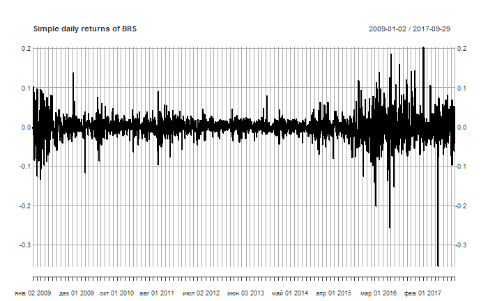

#### RDY

The data seems stable: daily returns rarely breach the [-0.05; 0.05] interval with the exception of outliers, most notable of them occurring on 2015-11-06 and 2016-07-26.

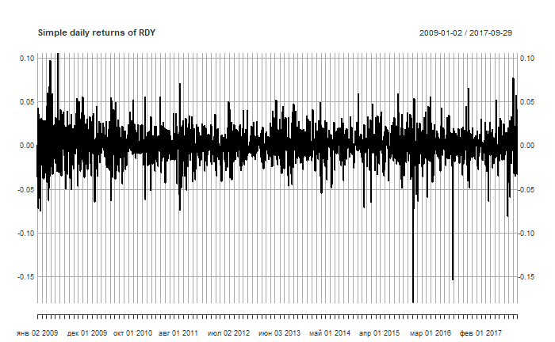

#### APC

There are periods of high volatility: they are rather short, but frequent, with outliers overstepping the 10% boundary.

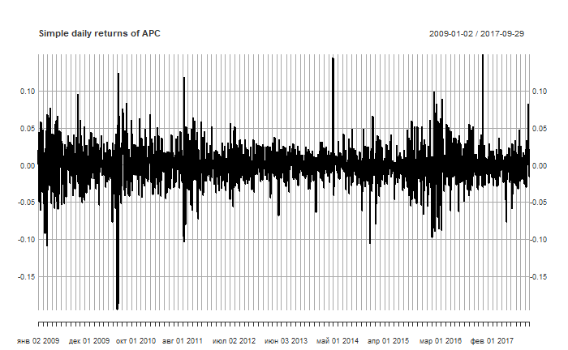

### S&P 500

As a stock market index, S&P 500 will only experience significant flunctuations only if the situation of the whole market is changing. There are periods of fading oscillations, however, even them breaching 4% is a rare event.

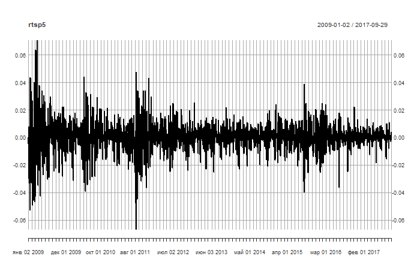

### Task (c)

> Compute the sample mean, standard deviation, skewness, excess kurtosis, minimum, and maximum of each simple return series. Comment on each statistic briefly.

#### BRS

The mean is almost zero, proving the hypothesis of stocks not being profitable in the long run. The standard error indicates that the data is close to the mean, and an investor may gain/lose around 3% each day.

Min and max value are influenced by outliers, indicating that in a day an investor might have lost 35%, however, he might have gained 20% on a different day as well.

The data is moderately skewed on the left side. The kurtosis value indicates very high weight of the distribution tales, meaning constant and significant in value deviations from zero. Overall, the distribution is far from normal.

|  | as.numeric.rtbrs |
| --- | --- |
| nobs | 2202.000000 |
| NAs | 0.000000 |
| Minimum | -0.355677 |
| Maximum | 0.203986 |
| 1. Quartile | -0.013191 |
| 3. Quartile | 0.013579 |
| Mean | 0.000049 |
| Median | 0.000548 |
| Sum | 0.107345 |
| SE Mean | 0.000677 |

[output cut: 6 more lines]

#### RDY

The mean is almost zero, proving the hypothesis of stocks not being profitable in the long run. The standard error indicates that the data is close to the mean, and an investor may gain/lose around 2% each day.

Min and max value are influenced by outliers, indicating that in a day an investor might have lost 18%, however, he might have gained 10-11% on a different day as well.

The data is moderately skewed on the left side. The kurtosis value indicates high weight of the distribution tales, meaning deviations from zero. Overall, the distribution is far from normal.

```r
basicStats(as.numeric(rtrdy))
```

|  | as.numeric.rtrdy |
| --- | --- |
| nobs | 2202.000000 |
| NAs | 0.000000 |
| Minimum | -0.180077 |
| Maximum | 0.105445 |
| 1. Quartile | -0.008816 |
| 3. Quartile | 0.010939 |
| Mean | 0.000754 |
| Median | 0.000802 |
| Sum | 1.660676 |
| SE Mean | 0.000409 |

[output cut: 6 more lines]

#### APC

The mean is almost zero, proving the hypothesis of stocks not being profitable in the long run. The standard error indicates that the data is close to the mean, and an investor may gain/lose around 2.5% a day.

Min and max value are influenced by outliers, indicating that in a day an investor might have lost 19%, however, he might have gained 15% on a different day as well.

udging by the skewness value, the data is fairly symmetrical. The kurtosis value indicates high weight of the distribution tales, meaning deviations from zero. Overall, the distribution cannot be considered normal.

```r
basicStats(as.numeric(rtapc))
```

|  | as.numeric.rtapc |
| --- | --- |
| nobs | 2202.000000 |
| NAs | 0.000000 |
| Minimum | -0.195490 |
| Maximum | 0.149435 |
| 1. Quartile | -0.012280 |
| 3. Quartile | 0.013117 |
| Mean | 0.000392 |
| Median | 0.000154 |
| Sum | 0.863381 |
| SE Mean | 0.000528 |

[output cut: 6 more lines]

#### S&P 500

The mean is close to zero, proving the hypothesis of stocks not being profitable in the long run. The standard error indicates that the data is close to the mean, and an investor may gain/lose around 1% a day on the market.

Min and max value are influenced by outliers (however, they seem much closer to the standard deviation than individual stocks), indicating that in a day an investor might have lost 7%, however, he might have gained 7% on a different day as well (on the given market).

Judging by the skewness value, the data is fairly symmetrical. The kurtosis value indicates high weight of the distribution tales, meaning deviations from zero. Overall, the distribution cannot be considered normal.

```r
basicStats(as.numeric(rtsp5))
```

|  | as.numeric.rtsp5 |
| --- | --- |
| nobs | 2202.000000 |
| NAs | 0.000000 |
| Minimum | -0.066634 |
| Maximum | 0.070758 |
| 1. Quartile | -0.003604 |
| 3. Quartile | 0.005344 |
| Mean | 0.000508 |
| Median | 0.000572 |
| Sum | 1.117860 |
| SE Mean | 0.000225 |

[output cut: 6 more lines]

### Task (d)

> Obtain the histogram and the estimate of density of the simple returns for all time series. Impose the theoretical normal density on your histogram. Do the returns seem to be normally distributed?

The following function is used to plot histograms:

```r
plot_hist = function(stock_returns, stock_name, xlim=c(-0.3, 0.3)){
  hist(as.numeric(stock_returns), breaks=100, prob=T, xlim = xlim, main=paste('Histogram of simple daily returns — ', stock_name))
  lines(density(as.numeric(stock_returns)))
  curve(dnorm(x, mean(as.numeric(stock_returns)), sd(as.numeric(stock_returns))), from=xlim[1], to=xlim[2], add=T, col='red')
}
```

#### BRS

Evidently, the distribution cannot be considered normal.

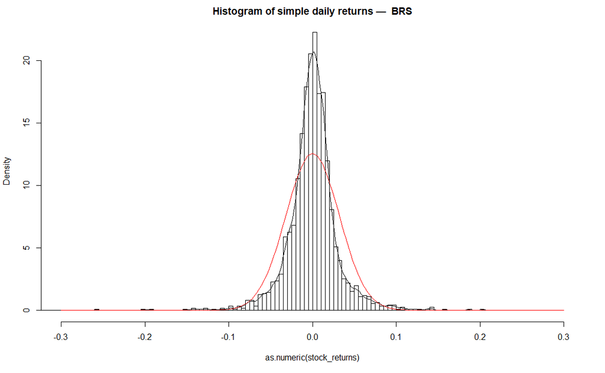

#### RDY

Disregarding the high peak, the data is rather close to the normal distribution, however, it still cannot be considered as such.

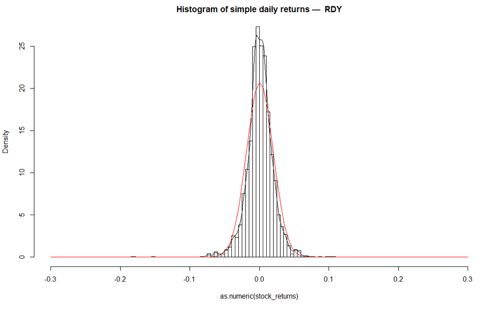

#### APC

Evidently, the sample distribution cannot be considered normal.

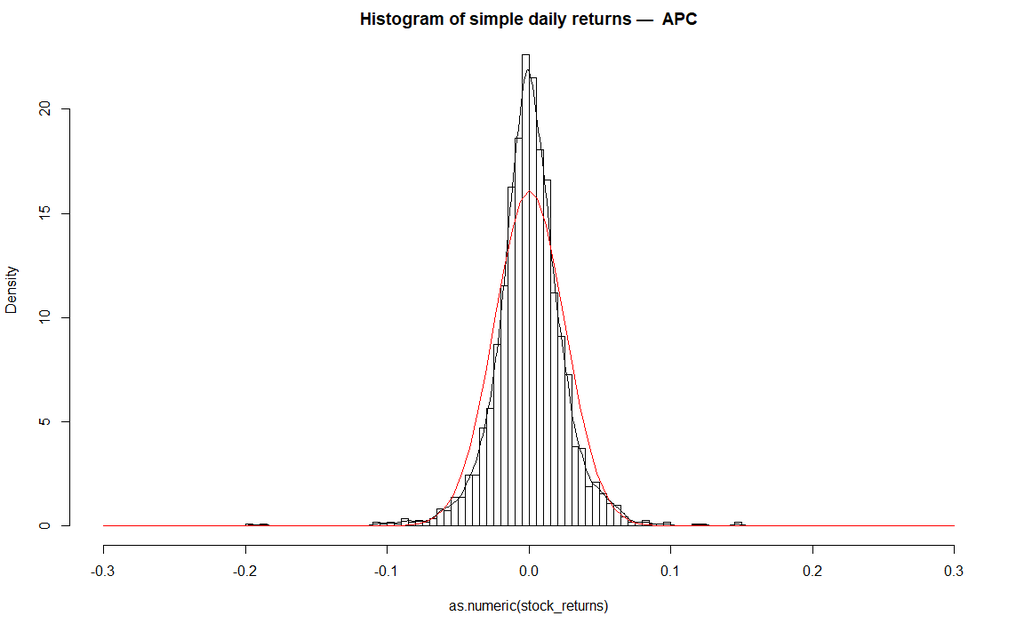

#### S&P 500

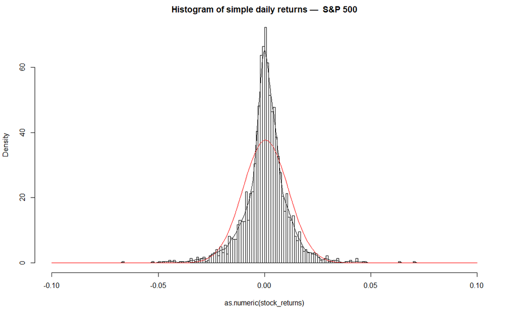

Overall, neither of the sample distributions cannot be considered normal.

### Task (e)

> Obtain a qq-plot using command qq.plot() from package car and comment on that.

#### BRS

As easily observed from the Q-Q plot, the distribution cannot be considered normal: the tails are too “heavy”.

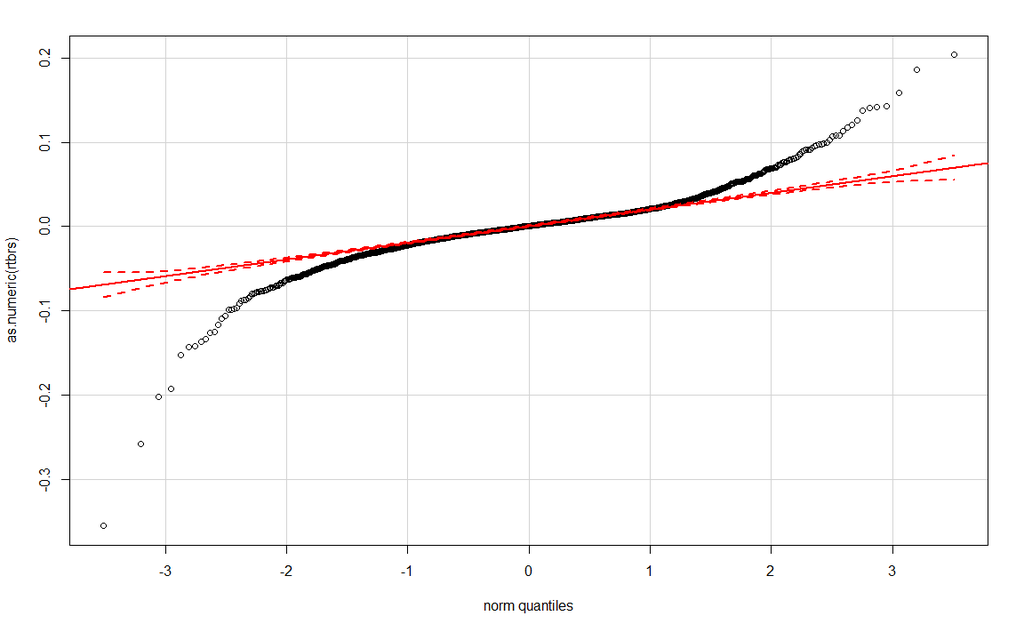

#### RDY

This one is actually closer to the normal distribution, but the tails here are too “heavy” for the normal distribution as well.

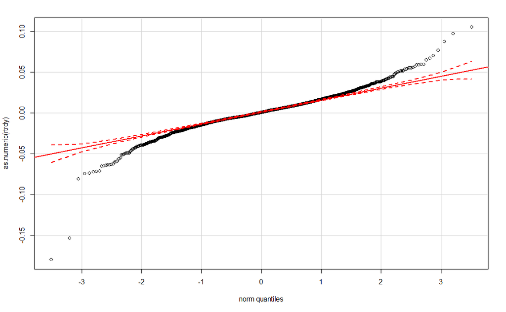

#### APC

Again, the data is clearly not drawn from the normal distribution.

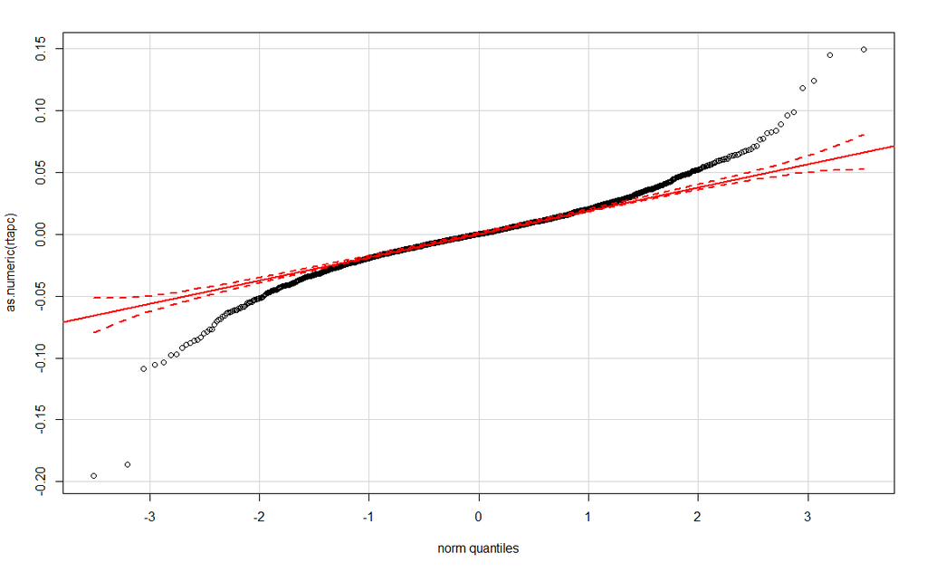

#### S&P 500

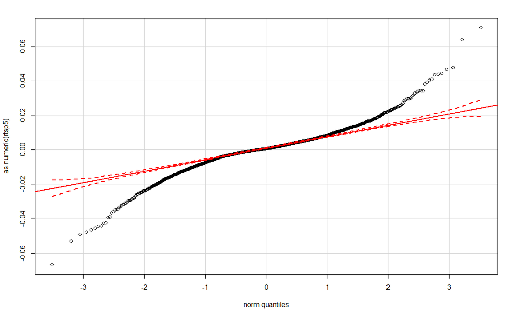

To sum up, the Q-Q plots testified for non-normality of the sample distributions.

### Task (f)

> Perform the Jarque-Bera normality test.

The null hypothesis of the Jarque–Bera test states that data is drawn from a normal distribution (more precisely, the sample skewness (S) equals zero, the sample kurtosis (K) - 3). The alternative hypothesis is that S <> 0, K <> 3. #### BRS Judging by the p-value, the null hypothesis should be rejected, meaning the data is not normally distributed.

```r
jarqueberaTest(as.numeric(rtbrs))
```

```
Title:
 Jarque - Bera Normalality Test

Test Results:
  STATISTIC:
    X-squared: 18121.7467
  P VALUE:
    Asymptotic p Value: < 2.2e-16

Description:
 Sat Sep 30 23:51:09 2017 by user: koxre
```

#### RDY

Judging by the p-value, the null hypothesis should be rejected, meaning the data is not normally distributed.

```r
jarqueberaTest(as.numeric(rtrdy))
```

```
Title:
 Jarque - Bera Normalality Test

Test Results:
  STATISTIC:
    X-squared: 4915.8279
  P VALUE:
    Asymptotic p Value: < 2.2e-16

Description:
 Sat Sep 30 23:51:09 2017 by user: koxre
```

#### APC

Judging by the p-value, the null hypothesis should be rejected, meaning the data is not normally distributed.

```r
jarqueberaTest(as.numeric(rtapc))
```

```
Title:
 Jarque - Bera Normalality Test

Test Results:
  STATISTIC:
    X-squared: 3229.6947
  P VALUE:
    Asymptotic p Value: < 2.2e-16

Description:
 Sat Sep 30 23:51:10 2017 by user: koxre
```

#### S&P 500

Judging by the p-value, the null hypothesis should be rejected, meaning the data is not normally distributed.

```r
jarqueberaTest(as.numeric(rtsp5))
```

```
Title:
 Jarque - Bera Normalality Test

Test Results:
  STATISTIC:
    X-squared: 2368.6451
  P VALUE:
    Asymptotic p Value: < 2.2e-16

Description:
 Sat Sep 30 23:51:10 2017 by user: koxre
```

### Task (g)

> Transform the simple returns to log returns. Compute the sample mean, standard deviation, skewness, excess kurtosis, minimum, and maximum of each log return series. Comment on each statistic briefly.

First, the log returns will be precomputed:

```r
logrtbrs = na.omit(as.numeric(diff(log(brs))))
logrtrdy = na.omit(as.numeric(diff(log(rdy))))
logrtapc = na.omit(as.numeric(diff(log(apc))))
logrtsp5 = na.omit(as.numeric(diff(log(sp5))))
```

#### BRS

The mean is almost zero, proving the hypothesis of stocks not being profitable in the long run. The standard error indicates that the data is close to the mean, with variation of roughly 3%.

Min and max value are influenced by outliers, indicating that in a day an investor might have lost 44% in log returns, however, he might have gained 18-19% on a different day as well.

The data is moderately skewed to the left. The kurtosis value indicates very high weight of the distribution tales, meaning constant and significant in value deviations from zero. Overall, the distribution is far from normal.

```r
basicStats(logrtbrs)
```

|  | logrtbrs |
| --- | --- |
| nobs | 2201.000000 |
| NAs | 0.000000 |
| Minimum | -0.439555 |
| Maximum | 0.185638 |
| 1. Quartile | -0.013294 |
| 3. Quartile | 0.013491 |
| Mean | -0.000469 |
| Median | 0.000562 |
| Sum | -1.031909 |
| SE Mean | 0.000692 |

[output cut: 6 more lines]

#### RDY

The mean is almost zero, proving the hypothesis of stocks not being profitable in the long run. The standard error indicates that the data is close to the mean, with variation of roughly 2%.

Min and max value are influenced by outliers, indicating that in a day an investor might have lost 20% in log returns, however, he might have gained 10% on a different day as well.

The data is moderately skewed to the left. The kurtosis value indicates high weight of the distribution tales, meaning constant deviations from zero. Overall, the distribution is far from normal.

```r
basicStats(logrtrdy)
```

|  | logrtrdy |
| --- | --- |
| nobs | 2201.000000 |
| NAs | 0.000000 |
| Minimum | -0.198544 |
| Maximum | 0.100248 |
| 1. Quartile | -0.008856 |
| 3. Quartile | 0.010906 |
| Mean | 0.000568 |
| Median | 0.000807 |
| Sum | 1.251223 |
| SE Mean | 0.000412 |

[output cut: 6 more lines]

#### APC

The mean is almost zero, proving the hypothesis of stocks not being profitable in the long run. The standard error indicates that the data is close to the mean, with variation of roughly 2%.

Min and max value are influenced by outliers, indicating that in a day an investor might have lost 22% in log returns, however, he might have gained 14% on a different day as well.

The data is moderately skewed to the left. The kurtosis value indicates high weight of the distribution tales, meaning constant deviations from zero. Overall, the distribution is far from normal.

```r
basicStats(logrtapc)
```

|  | logrtapc |
| --- | --- |
| nobs | 2201.000000 |
| NAs | 0.000000 |
| Minimum | -0.217522 |
| Maximum | 0.139270 |
| 1. Quartile | -0.012365 |
| 3. Quartile | 0.013036 |
| Mean | 0.000084 |
| Median | 0.000159 |
| Sum | 0.184494 |
| SE Mean | 0.000531 |

[output cut: 6 more lines]

#### S&P 500

Min and max value are influenced by outliers, indicating that in a day an investor might have lost 7% in log returns, however, he might have gained 7% on a different day as well.

The data is fairly symmetrical. The kurtosis value indicates high weight of the distribution tales, meaning constant deviations from zero. Overall, the distribution is not normal.

```r
basicStats(logrtsp5)
```

|  | logrtsp5 |
| --- | --- |
| nobs | 2201.000000 |
| NAs | 0.000000 |
| Minimum | -0.068958 |
| Maximum | 0.068366 |
| 1. Quartile | -0.003616 |
| 3. Quartile | 0.005339 |
| Mean | 0.000452 |
| Median | 0.000574 |
| Sum | 0.994642 |
| SE Mean | 0.000225 |

[output cut: 6 more lines]

### Task (h)

> Test the null hypothesis that the mean of the log returns is zero.

The null hypothesis of the t-test states the population mean equals zero. The alternative hypothesis states otherwise. #### BRS The p-value indicates that the null hypothesis cannot be rejected, therefore, the population mean can be considered as equal to zero.

```r
t.test(logrtbrs)
```

```
    One Sample t-test

data:  logrtbrs
t = -0.67785, df = 2200, p-value = 0.4979
alternative hypothesis: true mean is not equal to 0
95 percent confidence interval:
 -0.0018251944  0.0008875219
sample estimates:
    mean of x
-0.0004688363
```

#### RDY

The p-value indicates that the null hypothesis cannot be rejected, therefore, the population mean can be considered as equal to zero.

```r
t.test(logrtrdy)
```

```
    One Sample t-test

data:  logrtrdy
t = 1.3797, df = 2200, p-value = 0.1678
alternative hypothesis: true mean is not equal to 0
95 percent confidence interval:
 -0.0002395359  0.0013764942
sample estimates:
   mean of x
0.0005684792
```

#### APC

The p-value indicates that the null hypothesis cannot be rejected, therefore, the population mean can be considered as equal to zero.

```r
t.test(logrtapc)
```

```
    One Sample t-test

data:  logrtapc
t = 0.15797, df = 2200, p-value = 0.8745
alternative hypothesis: true mean is not equal to 0
95 percent confidence interval:
 -0.0009567571  0.0011244026
sample estimates:
   mean of x
8.382273e-05
```

#### S&P 500

The p-value indicates that the null hypothesis should be rejected, as such, the population mean cannot be considered as equal to zero.

```r
t.test(logrtsp5)
```

```
    One Sample t-test

data:  logrtsp5
t = 2.0045, df = 2200, p-value = 0.04514
alternative hypothesis: true mean is not equal to 0
95 percent confidence interval:
 9.787771e-06 8.940214e-04
sample estimates:
   mean of x
0.0004519046
```

### Task (i)

> Perform the Jarque-Bera normality test for log returns.

The null hypothesis of the test is stated above.

#### BRS

Judging by the p-value, the null hypothesis should be rejected, meaning the data is not normally distributed.

```r
jarqueberaTest(logrtbrs)
```

```
Title:
 Jarque - Bera Normalality Test

Test Results:
  STATISTIC:
    X-squared: 49727.3361
  P VALUE:
    Asymptotic p Value: < 2.2e-16

Description:
 Sat Sep 30 23:51:10 2017 by user: koxre
```

#### RDY

Judging by the p-value, the null hypothesis should be rejected, meaning the data is not normally distributed.

```r
jarqueberaTest(logrtrdy)
```

```
Title:
 Jarque - Bera Normalality Test

Test Results:
  STATISTIC:
    X-squared: 8116.7209
  P VALUE:
    Asymptotic p Value: < 2.2e-16

Description:
 Sat Sep 30 23:51:10 2017 by user: koxre
```

#### APC

Judging by the p-value, the null hypothesis should be rejected, meaning the data is not normally distributed.

```r
jarqueberaTest(logrtapc)
```

```
Title:
 Jarque - Bera Normalality Test

Test Results:
  STATISTIC:
    X-squared: 4809.5703
  P VALUE:
    Asymptotic p Value: < 2.2e-16

Description:
 Sat Sep 30 23:51:10 2017 by user: koxre
```

#### S&P 500

Judging by the p-value, the null hypothesis should be rejected, meaning the data is not normally distributed.

```r
jarqueberaTest(logrtsp5)
```

```
Title:
 Jarque - Bera Normalality Test

Test Results:
  STATISTIC:
    X-squared: 2392.7013
  P VALUE:
    Asymptotic p Value: < 2.2e-16

Description:
 Sat Sep 30 23:51:10 2017 by user: koxre
```

### Task (j)

> Obtain the histogram and the empirical density plot of the daily log returns.

```r
plot_hist_log = function(stock_returns, stock_name, xlim=c(-0.3, 0.3)){
  hist(as.numeric(stock_returns), breaks=100, prob=T, xlim = xlim, main=paste('Histogram of log daily returns — ', stock_name), xlab = paste('log returns', stock_name))
  lines(density(as.numeric(stock_returns)))
}
```

#### BRS

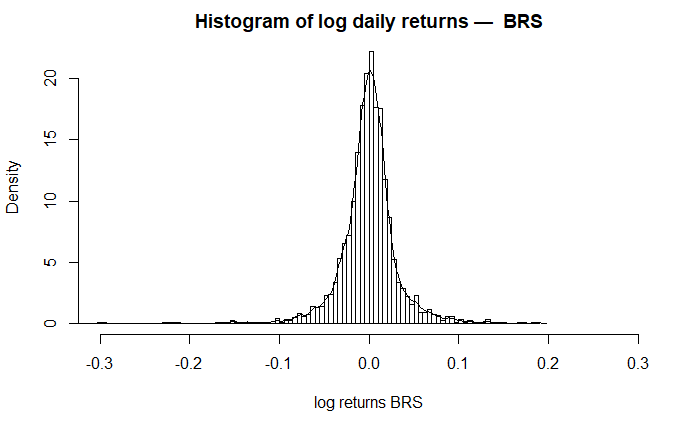

```r
plot_hist_log(logrtbrs, 'BRS')
```

#### RDY

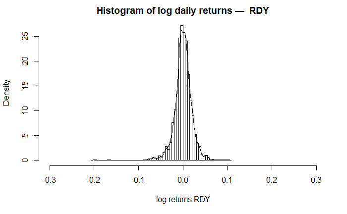

```r
plot_hist_log(logrtrdy, 'RDY')
```

#### APC

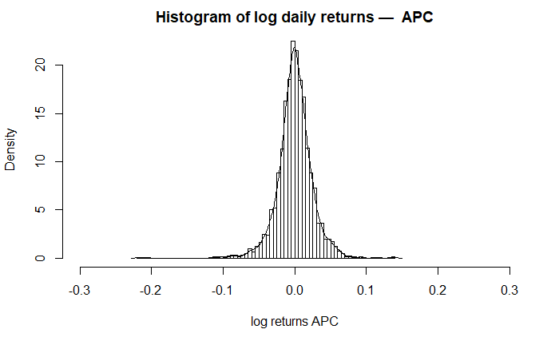

```r
plot_hist_log(logrtapc, 'APC')
```

#### S&P 500

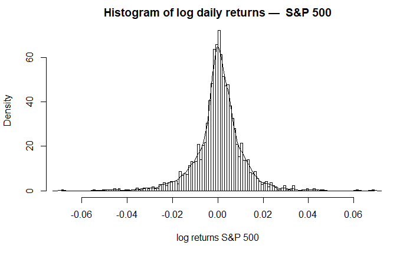

```r
plot_hist_log(logrtsp5, 'S&P 500', c(-0.07, 0.07))
```

#### Task (k)

> Compute the Pearson’s correlation, Kendall’s tau and Spearman’s rank correlations between the log returns of the three stocks and the S&P 500 index. Construct the respective scatter plots. Comment on the results.

```r
correl = function(log_rt) {
  plot(log_rt,logrtsp5)
  cat('Pearson correlation: ', cor(log_rt, logrtsp5), '\n')
  cat("Spearman's rank correlation: ", cor(log_rt, logrtsp5, method='spearman'), '\n')
  cat("Kendall's tau: ", cor(log_rt, logrtsp5, method='kendall'), '\n')
}
```

#### BRS

There is some linearity present between the datasets, testified by correlation coefficients. It means the behaviour can be partly explained by using a linear model.

```
Pearson correlation:  0.4659087
Spearman's rank correlation:  0.5491788
Kendall's tau:  0.3888965
```

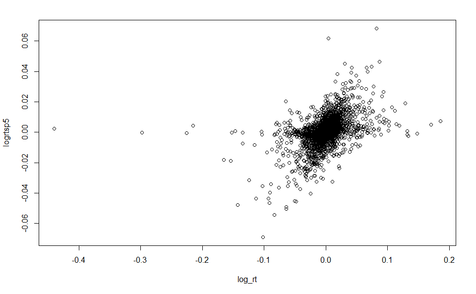

```r
correl(logrtbrs)
```

#### RDY

There is some linearity in the datasets as well, meaning it is possible to construct a linear model based on the data.

```
Pearson correlation:  0.4414681
Spearman's rank correlation:  0.4365812
Kendall's tau:  0.3064119
```

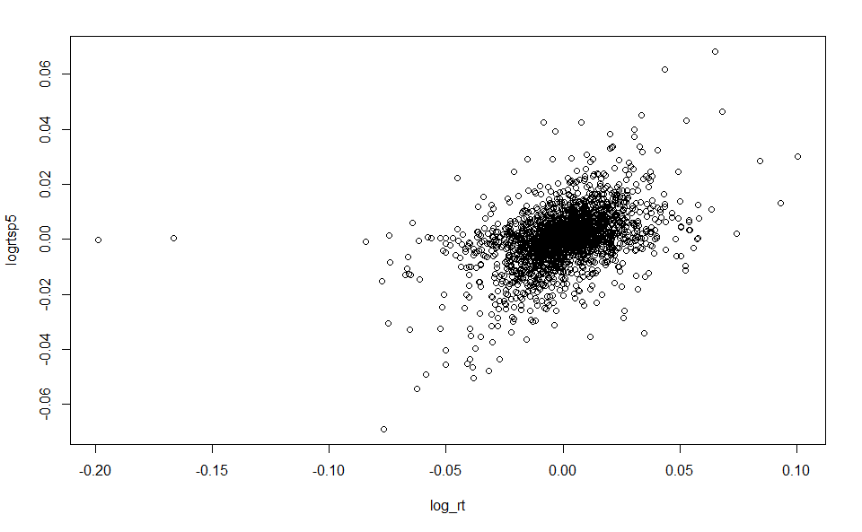

```r
correl(logrtrdy)
```

#### APC

```
Pearson correlation:  0.6347284
Spearman's rank correlation:  0.6160878
Kendall's tau:  0.4483601
```

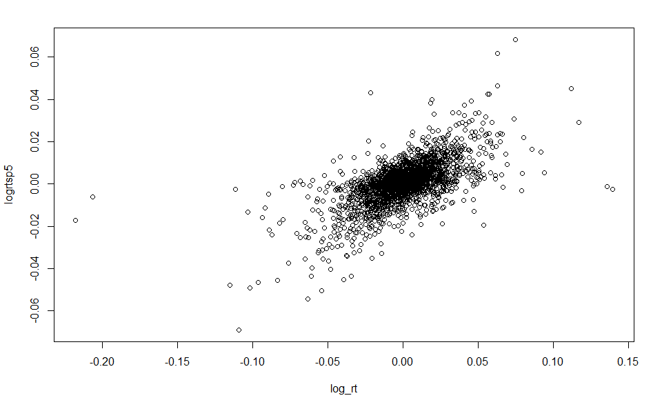

```r
correl(logrtapc)
```